# Json Assignment

Victor Torres

2024-03-19

## Introduction.

#### For this assignment, we will be working with two JSON files available through the API at nobelprize.org, ask 4 interesting questions and answer using data analysis.

## Load Packages Required for the Project

```r
library(tidyverse)
library(dplyr)
library(jsonlite)
library(httr2)
```

## Load Json files into R

#### I will get the prize and the Prize and Laureate files.

```r
nobel_prize <- "http://api.nobelprize.org/v1/prize.json"
nobel_laureate <- "http://api.nobelprize.org/v1/laureate.json"
# read data from json files
nobelPrize <- fromJSON(nobel_prize)
nobelLaureate <- fromJSON(nobel_laureate)
# display names of main keys in the JSON files
names(nobelPrize)
```

```
## [1] "prizes"
```

```r
names(nobelLaureate)
```

```
## [1] "laureates"
```

```r
# examine sub elements in files
names(nobelPrize$prizes)
```

```
## [1] "year"              "category"          "laureates"
## [4] "overallMotivation"
```

```r
names(nobelLaureate$laureates)
```

```
##  [1] "id"              "firstname"       "surname"         "born"
##  [5] "died"            "bornCountry"     "bornCountryCode" "bornCity"
##  [9] "diedCountry"     "diedCountryCode" "diedCity"        "gender"
## [13] "prizes"
```

## Start cleaning and tyding data, as well as to create a data frame.

```r
nobelPrize <- nobelPrize$prizes %>%
  unnest_wider(laureates) %>%
  unnest(id, firstname, surname, motivation, share)
# Create Data Frames with JSON Data
df_nobelPrize <- bind_rows(nobelPrize)
df_nobelLaureate <- bind_rows(nobelLaureate)

# Combine the two data frames by id to start asking questions
join_df <- inner_join(df_nobelPrize, df_nobelLaureate, by = "id") %>%
  select(-c("firstname.y", "surname.y", "prizes")) %>%
  as.data.frame()

head(join_df)
```

```
##   year   category   id firstname.x surname.x
## 1 2023  chemistry 1029      Moungi   Bawendi
## 2 2023  chemistry 1030       Louis      Brus
## 3 2023  chemistry 1031     Aleksey   Yekimov
## 4 2023  economics 1034     Claudia    Goldin
## 5 2023 literature 1032         Jon     Fosse
## 6 2023      peace 1033      Narges Mohammadi
##                                                                                                          motivation
## 1                                                                 "for the discovery and synthesis of quantum dots"
## 2                                                                 "for the discovery and synthesis of quantum dots"
## 3                                                                 "for the discovery and synthesis of quantum dots"
## 4                                         "for having advanced our understanding of women’s labour market outcomes"
## 5                                            "for his innovative plays and prose which give voice to the unsayable"
## 6 "for her fight against the oppression of women in Iran and her fight to promote human rights and freedom for all"
##   share overallMotivation       born       died       bornCountry
```

[output cut: 20 more lines]

## Question 1: what is the country with most novel prize winners?

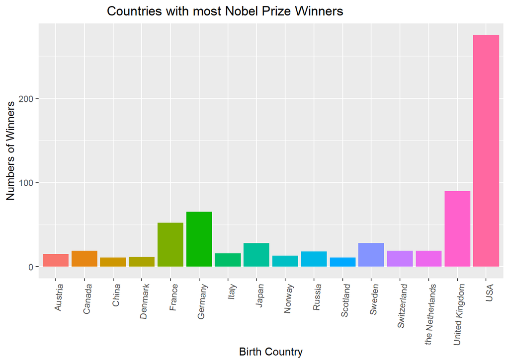

```r
join_df %>%
    group_by(bornCountry) %>%
  top_n(15) %>%
  filter(n() > 10) %>%
  filter(!is.na(bornCountry)) %>%
  ggplot() +
  geom_bar(aes(x = bornCountry, fill = bornCountry)) +
  ggtitle("Countries with most Nobel Prize Winners") +
  ylab("Numbers of Winners") +
  xlab("Birth Country") +
  theme(plot.title = element_text(hjust = 0.3),
        plot.subtitle = element_text(hjust = 0.3),
        legend.title = element_blank(),
        legend.position = "none",
        axis.text.x = element_text(angle = 85, hjust = 1))
```

#### Based on the data analysis and Graph, the country with most awards is USA with over two hundred awards.

## Question 2: What is the count of awards between male and female?

```r
print(join_df$gender)
```

[output not shown]

[output cut: 110 more lines]

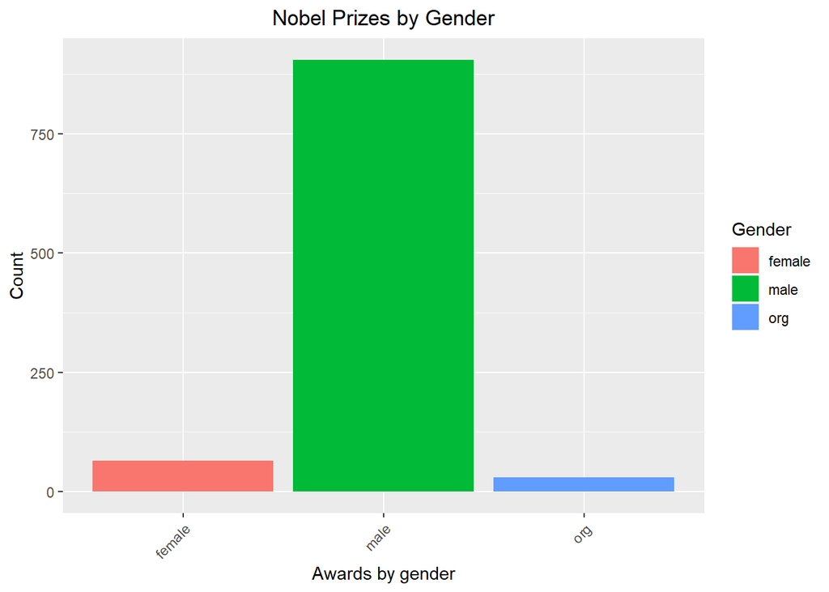

```r
join_df %>%
  group_by(gender) %>%
  ggplot() +
  geom_bar(aes(x = gender, fill = gender), position = "dodge") +
  ggtitle("Nobel Prizes by Gender") +
  xlab("Awards by gender") +
  ylab("Count") +
  theme(plot.title = element_text(hjust = 0.5),
        plot.subtitle = element_text(hjust = 0.5),
        axis.text.x = element_text(angle = 45, hjust = 1)) +
  labs(fill = "Gender")
```

#### Based on the graph above there is a huge difference of awards between male and female with over 800 awards for males against less than a 100 for females.

## Question 3: What is the count of awards winned by USA per category in the last century?

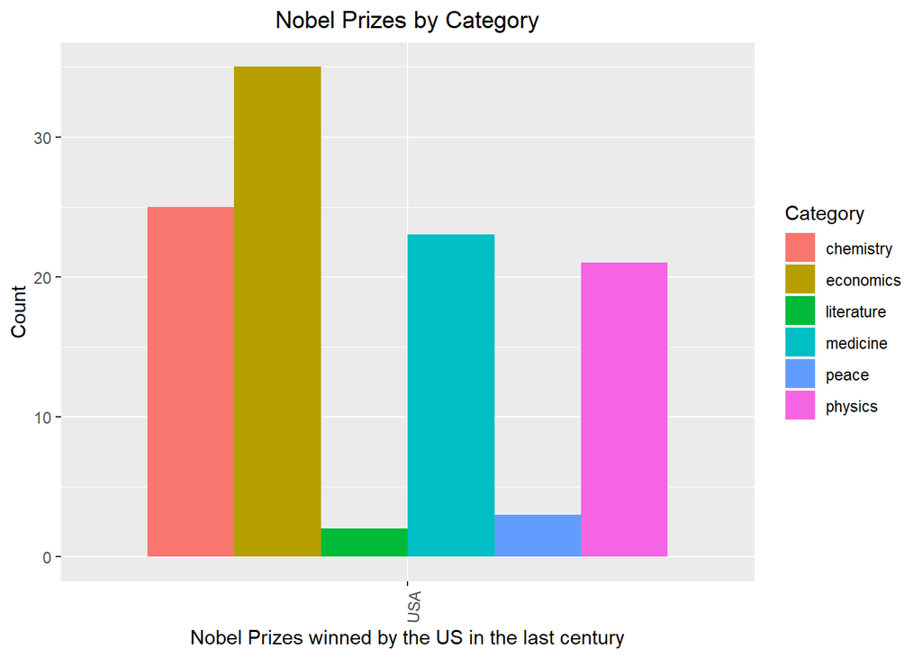

```r
join_df %>%
  group_by(bornCountry, category) %>%
  filter(year %in% 2000:2023) %>%
  filter(bornCountry %in% "USA") %>%
  ggplot() +
  geom_bar(aes(x = bornCountry, fill = category), position = "dodge") +
  ggtitle("Nobel Prizes by Category") +
  xlab("Nobel Prizes winned by the US in the last century") +
  ylab("Count") +
  theme(plot.title = element_text(hjust = 0.5),
        plot.subtitle = element_text(hjust = 0.5),
        axis.text.x = element_text(angle = 85, hjust = 1)) +
  labs(fill = "Category")
```

#### The most awards by category winned by the US is Economics with 35 in the 21st century.

## Question 3: number of females awarded per category in the last century?

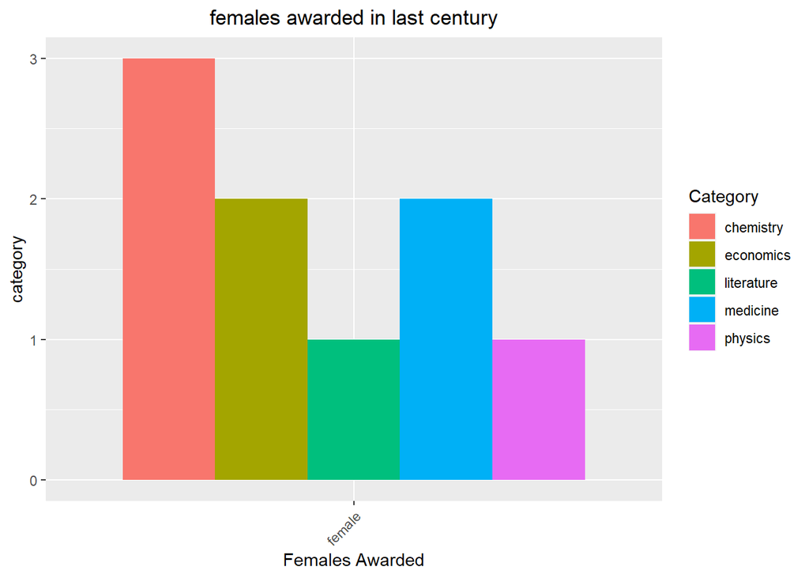

```r
join_df %>%
  group_by(gender, category) %>%
  filter(bornCountry %in% "USA") %>%
  filter(year %in% 2000:2023) %>%
  filter(gender %in% "female")%>%
      ggplot() +
      geom_bar(mapping = aes(x = gender, fill = category),position = "dodge")+
 ggtitle("females awarded in last century") +
  xlab("Females Awarded") +
  ylab("category") +
  theme(plot.title = element_text(hjust = 0.5),
        plot.subtitle = element_text(hjust = 0.5),
        axis.text.x = element_text(angle = 45, hjust = 1)) +
  labs(fill = "Category")
```

##### There is a total of 9 US females awarded with the nobel prize in the 21st century.

## Conclussion:

#### I was able to succesfully upload the JSON files, clean and organize the data and analize it, in order to answer the questions with data analysis.